# Take-home Exercise 1

Author

Htet Kay Khaing

Published

May 7, 2026

Modified

May 22, 2026

## 1. Overview/Background

Motor insurance portfolios usually contain many policies with no claims and a small number of policies with severe claim outcomes. Because of this, aggregate profitability can look acceptable even when selected segments are loss-making or highly volatile. This study uses visual analytics to examine the distribution of key variables and to identify portfolio factors that may influence profitability and volatility.

## 2. The tasks

1. **Apply suitable univariate visual analytics techniques** to explore the distributions and characteristics of numerical and categorical variables.
2. **Apply suitable bivariate visual analytics techniques** to investigate and statistically validate factors influencing the profitability and volatility of the insurance portfolio.

For this report, **profitability** is measured mainly using `underwriting_result` and `loss_ratio`. **Volatility** is examined using claim occurrence, claim frequency, the spread of loss ratio and upper-tail loss ratio behaviour.

**Note**

The analysis is exploratory. The statistical tests validate whether observed differences are unlikely to be random, but they do not prove direct causality. Business interpretation is still required because the dataset is observational.

## 3. Getting started

### 3.1 Installing and loading the packages

For this exercise, the following R packages will be used:

- **tidyverse** for data wrangling and ggplot2 visualisation,
- **scales** for formatting values,
- **patchwork** for combining plots,
- **ggdist** for raincloud-style distribution plots,
- **ggridges** for ridgeline plots, and
- **knitr** for report formatting support.

The following code chunk uses `p_load()` of **pacman** package to check if tidyverse packages are installed in the computer. If they are, the libraries will be called into R.

```r
pacman::p_load(tidyverse, scales, patchwork,
               ggdist, ggridges, knitr)
```

## 4. The Data

### 4.1 Data import

The data file used is [Dataset of motor insurance portfolio.csv](https://data.mendeley.com/datasets/sw4jmdb2sm/1). The file is semicolon-delimited, so `read_delim()` is used instead of `read_csv()`.

```r
motor_raw <- read_delim(
  "data/Dataset of motor insurance portfolio.csv",
  delim = ";",
  show_col_types = FALSE
)
# glimpse(motor_raw)
```

### 4.2 Data overview

Dataset overview: Motor insurance portfolio transaction records

| metric | value |
| --- | --- |
| Number of records | 354,140 |
| Number of variables | 47 |
| Unique insured IDs | 185,678 |
| Years covered | 2022, 2023, 2024 |
| Total premium | $105,079,669 |
| Total incurred claims | $73,864,811 |
| Total claims | 77,099 |
| Total exposure | 250,325.9 |

The dataset has **354,140** records and **47** variables. It covers policy transaction records from **2022, 2023, 2024**, which allows both cross-sectional and time-based portfolio analysis.

### 4.3 Data Cleaning

**Check Missing Values**

Variables with missing values

| variable | missing_records | missing_pct |
| --- | --- | --- |
| fuel_type | 1,287 | 0.36% |
| vehicle_value | 513 | 0.14% |
| vehicle_age | 2 | 0.00% |
| age_driving_licence | 2 | 0.00% |

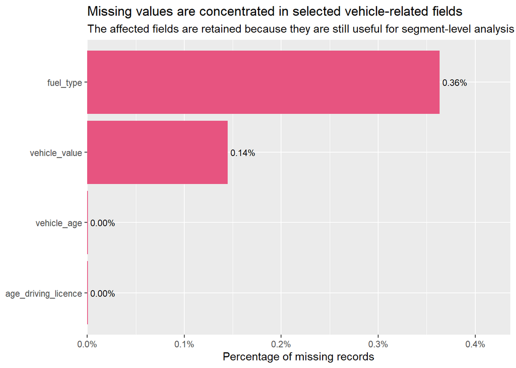

The missing value check shows that only four variables have a small portion of missing values: `fuel_type`, `vehicle_value`, `vehicle_age` and `age_driving_licence`.

For this exercise, missing values will not be removed because the main profitability and volatility measures, such as premium, claims, incurred amount and exposure, are still available. Removing rows with minor missing values may unnecessarily distort the portfolio-level analysis.

**Check duplicates**

Duplicate records are checked to ensure that there are no repeated rows. If exact duplicates are found, they should be removed because they may represent repeated transaction records. However, repeated `insured_id` values alone should not be treated as duplicates, as the same customer may have multiple policy records across years or policy types.

```r
duplicate_records <- sum(duplicated(motor_raw))
duplicate_pct <- duplicate_records / nrow(motor_raw)

duplicate_tbl <- data.frame(
  Check = "Exact duplicate rows across all variables",
  Duplicate_Records = comma(duplicate_records),
  Duplicate_Percentage = percent(duplicate_pct, accuracy = 0.01)
)

knitr::kable(
  duplicate_tbl,
  caption = "Duplicate records check"
)
```

Duplicate records check

| Check | Duplicate_Records | Duplicate_Percentage |
| --- | --- | --- |
| Exact duplicate rows across all variables | 0 | 0.00% |

### 4.4 Data Preparation

#### 4.4.1 Deriving analytical variables

The raw dataset includes premium, incurred claims, number of claims and exposure. To investigate profitability and volatility, derived fields are created:

- `underwriting_result` = total premium minus total incurred claims,
- `loss_ratio` = total incurred claims divided by total premium,
- `claim_flag` = whether the record has at least one claim, and
- `loss_ratio_capped` = loss ratio capped at the 99th percentile for visualisation readability.

These derived fields are sufficient for the study objectives. `underwriting_result` and `loss_ratio` are used to assess profitability, while `claim_flag` and `loss_ratio_capped` help examine claim occurrence and volatility. Other variables are retained in their original form to keep the analysis simple and interpretable.

```r
motor_prep <- mutate(
  motor_raw,
  year = as.factor(year),
  policy_type = as.factor(policy_type),
  policy_status = as.factor(policy_status),
  business_type = as.factor(business_type),
  payment_frequency = as.factor(payment_frequency),
  underwriting_result = total_premium - total_incurred,
  loss_ratio = if_else(total_premium > 0, total_incurred / total_premium, NA_real_),
  claim_flag = total_claims > 0
)

motor_prep <- filter(
  motor_prep,
  total_premium > 0,
  total_exposure > 0
)

loss_ratio_cap_value <- quantile(motor_prep$loss_ratio, 0.99, na.rm = TRUE)

motor <- mutate(
  motor_prep,
  loss_ratio_capped = pmin(loss_ratio, loss_ratio_cap_value)
)
```

**Note**

`loss_ratio_capped` is used only for visualisation and non-parametric tests. Portfolio profitability calculations still use the original premium and incurred claim values.

#### 4.4.2 Portfolio-level summary

```r
portfolio_summary <- summarise(
  motor,
  valid_records = n(),
  unique_insured = n_distinct(insured_id),
  total_premium = sum(total_premium, na.rm = TRUE),
  total_incurred = sum(total_incurred, na.rm = TRUE),
  underwriting_result = sum(underwriting_result, na.rm = TRUE),
  loss_ratio = sum(total_incurred, na.rm = TRUE) / sum(total_premium, na.rm = TRUE),
  total_claims = sum(total_claims, na.rm = TRUE),
  claim_record_rate = mean(claim_flag, na.rm = TRUE),
  p99_loss_ratio = quantile(loss_ratio, 0.99, na.rm = TRUE)
)

portfolio_display <- data.frame(
  Metric = c(
    "Valid records",
    "Unique insured customers",
    "Total premium",
    "Total incurred claims",
    "Underwriting result",
    "Portfolio loss ratio",
    "Total claims",
    "Claim record rate",
    "99th percentile loss ratio"
  ),
  Value = c(
    comma(portfolio_summary$valid_records),
    comma(portfolio_summary$unique_insured),
    dollar(portfolio_summary$total_premium, prefix = "$"),
    dollar(portfolio_summary$total_incurred, prefix = "$"),
    dollar(portfolio_summary$underwriting_result, prefix = "$"),
    percent(portfolio_summary$loss_ratio, accuracy = 0.1),
    comma(portfolio_summary$total_claims),
    percent(portfolio_summary$claim_record_rate, accuracy = 0.1),
    percent(portfolio_summary$p99_loss_ratio, accuracy = 0.1)
  )
)

knitr::kable(
  portfolio_display,
  caption = "Portfolio-level performance summary"
)
```

Portfolio-level performance summary

[output not shown]

The portfolio contains **354,091** transaction records after filtering for positive premium and exposure. These records belong to **185,677** unique customers, showing that some customers appear more than once for transactions or renewals.

The portfolio looks **profitable**. It collected about *$105.1 million* in premiums and incurred about *$73.9 million* in claims, giving a positive underwriting result of about *$31.2 million*. The portfolio loss ratio is **70.3%**, which is below 100%, so claims did not exceed premiums. Only **14.3%** of records had claims, which means most records did not make a claim. However, there were still **77,098** claims in total. This suggests that the volatility comes from policies with more expensive claims.

Overall, the portfolio is profitable overall, but further analysis is needed to find which variables are less profitable or more volatile.

## 5. Objective 1: Univariate Visual Analytics

This section applies suitable univariate visual analytics techniques to explore the distributions and characteristics of numerical and categorical variables.

### 5.1 Distribution of Key Financial Variables

Histograms are suitable for identifying skewness, zero inflation and long-tail behaviour in numerical variables.

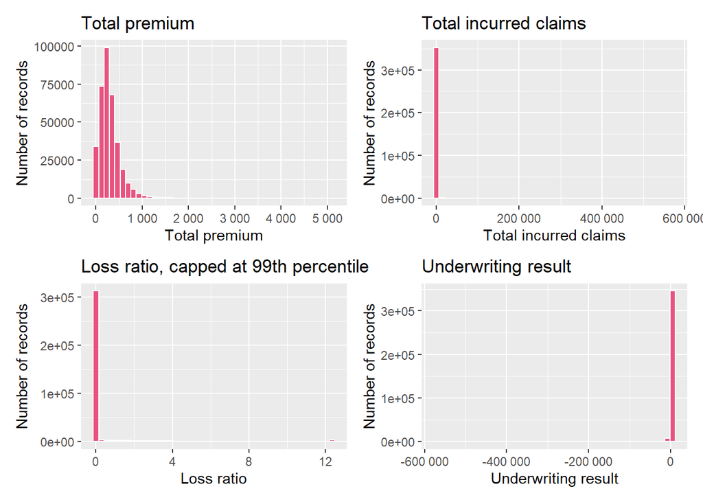

```r
p1 <- ggplot(motor, aes(x = total_premium)) +
  geom_histogram(bins = 45, fill = "#e75480", colour = "white") +
  scale_x_continuous(labels = label_number()) +
  labs(
    title = "Total premium",
    x = "Total premium",
    y = "Number of records"
  )

p2 <- ggplot(motor, aes(x = total_incurred)) +
  geom_histogram(bins = 45, fill = "#e75480", colour = "white") +
  scale_x_continuous(labels = label_number()) +
  labs(
    title = "Total incurred claims",
    x = "Total incurred claims",
    y = "Number of records"
  )

p3 <- ggplot(motor, aes(x = loss_ratio_capped)) +
  geom_histogram(bins = 45, fill = "#e75480", colour = "white") +
  scale_x_continuous(labels = label_number()) +
  labs(
    title = "Loss ratio, capped at 99th percentile",
    x = "Loss ratio",
    y = "Number of records"
  )

p4 <- ggplot(motor, aes(x = underwriting_result)) +
  geom_histogram(bins = 45, fill = "#e75480", colour = "white") +
  scale_x_continuous(labels = label_number()) +
  labs(
    title = "Underwriting result",
    x = "Underwriting result",
    y = "Number of records"
  )

p1 + p2 + p3 + p4
```

The distributions show that the financial variables are highly skewed. Most records have low premiums and little or no incurred claims, so the bars are heavily concentrated near zero. This means the portfolio is generally stable for most policies. However, the underwriting result shows a few large negative cases, suggesting that profitability can still be affected by a small number of high-claim records.

### 5.2 Distribution of Customer and Vehicle Characteristics

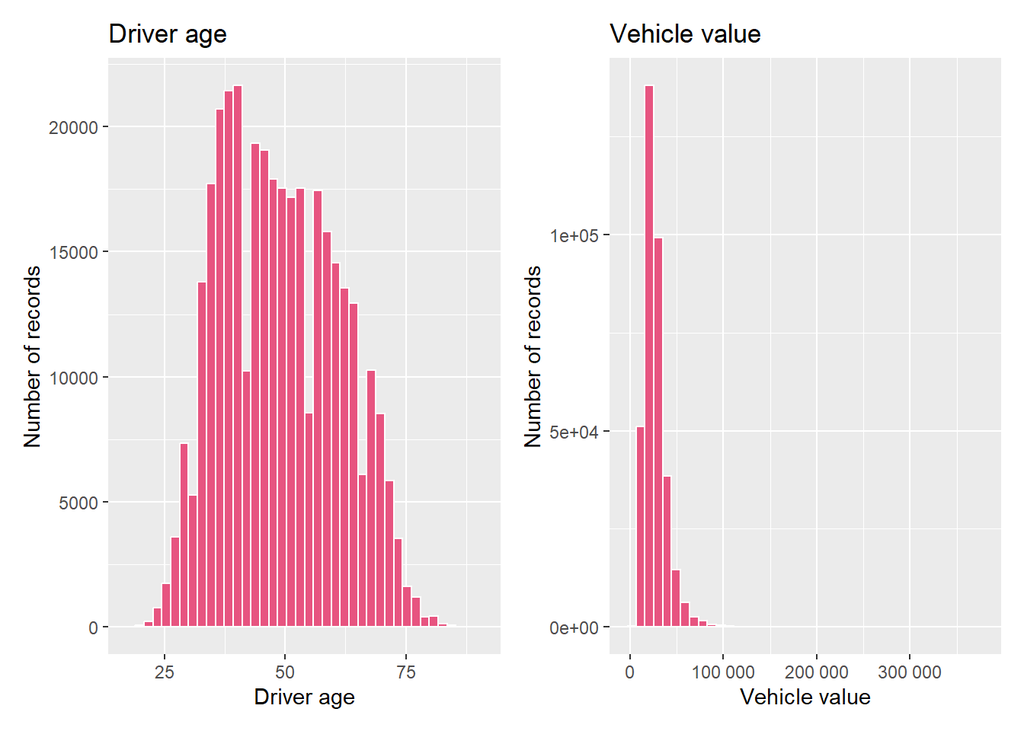

```r
p5 <- ggplot(motor, aes(x = driver_age)) +
  geom_histogram(bins = 40, fill = "#e75480", colour = "white") +
  labs(
    title = "Driver age",
    x = "Driver age",
    y = "Number of records"
  )

p6 <- ggplot(motor, aes(x = vehicle_value)) +
  geom_histogram(bins = 40, fill = "#e75480", colour = "white") +
  scale_x_continuous(labels = label_number()) +
  labs(
    title = "Vehicle value",
    x = "Vehicle value",
    y = "Number of records"
  )

p5 + p6
```

From the plot, we can say that most drivers are *middle-aged*, while vehicle value is highly skewed, meaning most vehicles have *lower values*, with only a small number of very high-value vehicles.

### 5.3 Distribution of Claim Count

Because claim count is a discrete numerical variable, a bar chart is more suitable than a histogram.

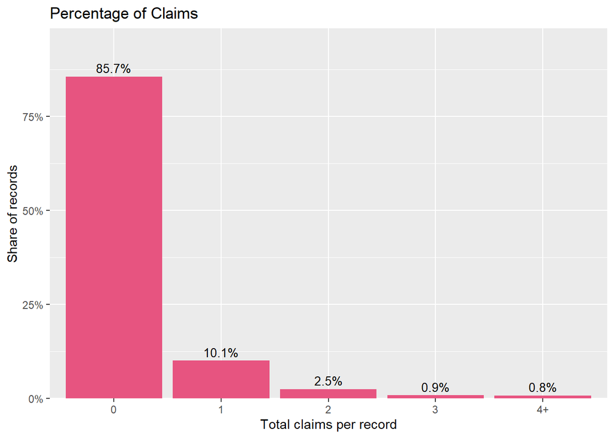

```r
claims_tbl <- mutate(
  motor,
  claims_group = if_else(total_claims >= 4, "4+", as.character(total_claims))
)

claims_tbl <- count(claims_tbl, claims_group)

claims_tbl <- mutate(
  claims_tbl,
  claims_group = factor(claims_group, levels = c("0", "1", "2", "3", "4+")),
  pct = n / sum(n)
)

ggplot(claims_tbl, aes(x = claims_group, y = pct)) +
  geom_col(fill = "#e75480") +
  geom_text(
    aes(label = percent(pct, accuracy = 0.1)),
    vjust = -0.4,
    size = 3.5
  ) +
  scale_y_continuous(
    labels = percent,
    expand = expansion(mult = c(0, 0.15))
  ) +
  labs(
    title = "Percentage of Claims",
    x = "Total claims per record",
    y = "Share of records"
  )
```

Most records did not make any claims, showing that claims are uncommon in the portfolio. This also explains portfolio risk is driven by the smaller number of records with claims.

### 5.4 Categorical portfolio composition

Bar charts are suitable for categorical variables because they show how portfolio volume is distributed across policy, status, business and payment frequency categories.

**Policy Type**

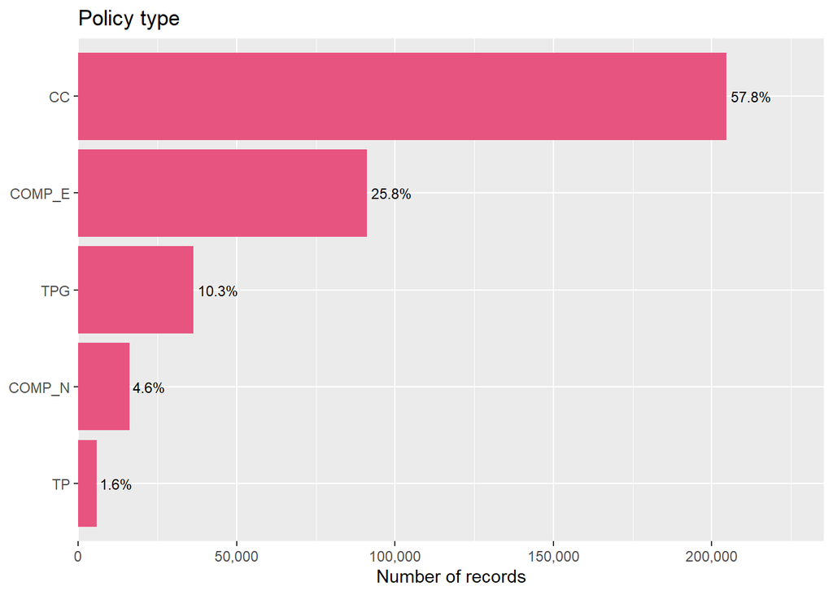

```r
policy_tbl <- count(motor, policy_type)
policy_tbl <- mutate(policy_tbl, pct = n / sum(n))

p_policy <- ggplot(policy_tbl, aes(x = n, y = fct_reorder(policy_type, n))) +
  geom_col(fill = "#e75480") +
  geom_text(aes(label = percent(pct, accuracy = 0.1)), hjust = -0.1, size = 3) +
  scale_x_continuous(labels = comma, expand = expansion(mult = c(0, 0.15))) +
  labs(
    title = "Policy type",
    x = "Number of records",
    y = NULL
  )
p_policy
```

**CC (Third-party liability)** is the dominant category, making up **57.8%** of records, followed by **COMP_E (comprehensive with excess)** at **25.8%**. The portfolio is mainly concentrated in these two product types.

**Policy Status**

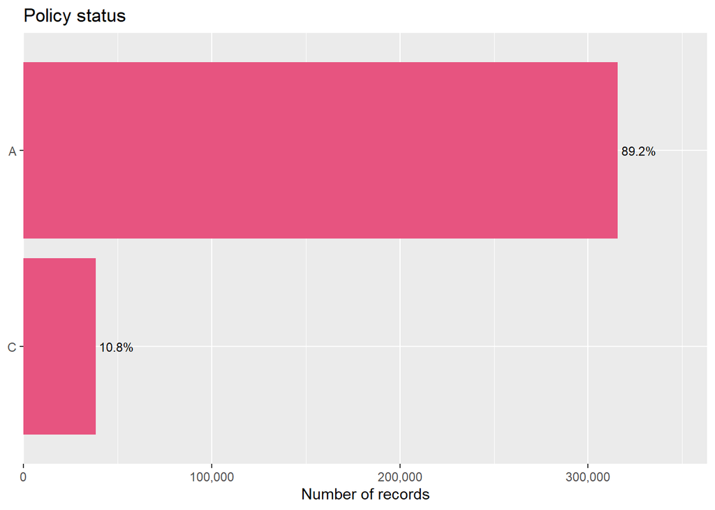

```r
status_tbl <- count(motor, policy_status)
status_tbl <- mutate(status_tbl, pct = n / sum(n))

p_status <- ggplot(status_tbl, aes(x = n, y = fct_reorder(policy_status, n))) +
  geom_col(fill = "#e75480") +
  geom_text(aes(label = percent(pct, accuracy = 0.1)), hjust = -0.1, size = 3) +
  scale_x_continuous(labels = comma, expand = expansion(mult = c(0, 0.15))) +
  labs(
    title = "Policy status",
    x = "Number of records",
    y = NULL
  )
p_status
```

Most records are active policies, accounting for **89.2%**. Although cancelled policies only accounts for **10.8%**, they should still be checked because it may affect profitability.

**Business Type**

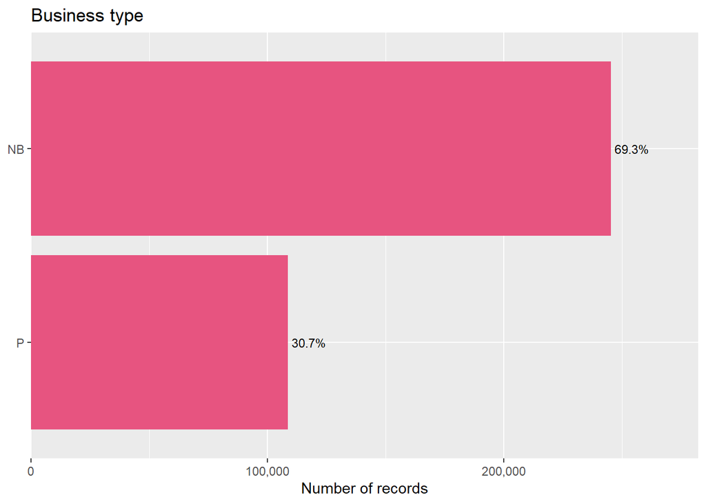

```r
business_tbl <- count(motor, business_type)
business_tbl <- mutate(business_tbl, pct = n / sum(n))

p_business <- ggplot(business_tbl, aes(x = n, y = fct_reorder(business_type, n))) +
  geom_col(fill = "#e75480") +
  geom_text(aes(label = percent(pct, accuracy = 0.1)), hjust = -0.1, size = 3) +
  scale_x_continuous(labels = comma, expand = expansion(mult = c(0, 0.15))) +
  labs(
    title = "Business type",
    x = "Number of records",
    y = NULL
  )
p_business
```

New business records make up **69.3%**. This suggests that the portfolio is more heavily driven by new policy transactions.

**Payment Frequency**

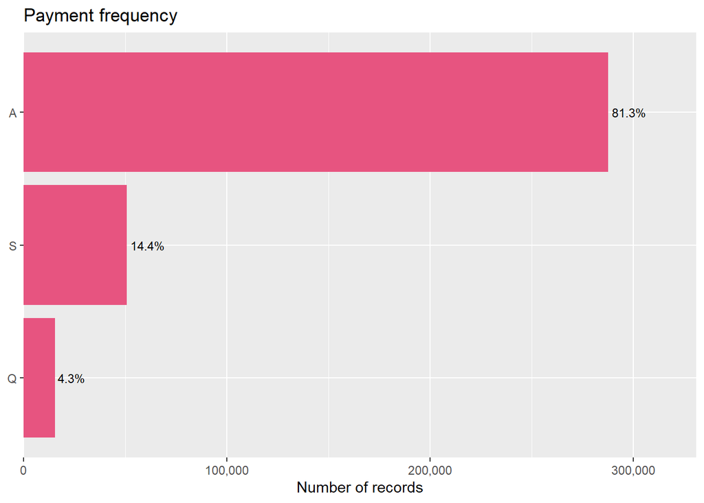

```r
payment_tbl <- count(motor, payment_frequency)
payment_tbl <- mutate(payment_tbl, pct = n / sum(n))

p_payment <- ggplot(payment_tbl, aes(x = n, y = fct_reorder(payment_frequency, n))) +
  geom_col(fill = "#e75480") +
  geom_text(aes(label = percent(pct, accuracy = 0.1)), hjust = -0.1, size = 3) +
  scale_x_continuous(labels = comma, expand = expansion(mult = c(0, 0.15))) +
  labs(
    title = "Payment frequency",
    x = "Number of records",
    y = NULL
  )
p_payment
```

**Annual** payment is the most common at **81.3%**. **Semi-annual** and **quarterly** payments are much smaller groups, but they maybe still useful for analysis because payment behaviour can be related to customer profile and profitability.

## 6. Objective 2: Bivariate Visual Analytics

This section applies suitable bivariate visual analytics techniques to investigate factors influencing portfolio profitability and volatility. Statistical validation is included to check whether the visual differences are supported by formal tests.

### 6.1 Profitability and Volatility over Time

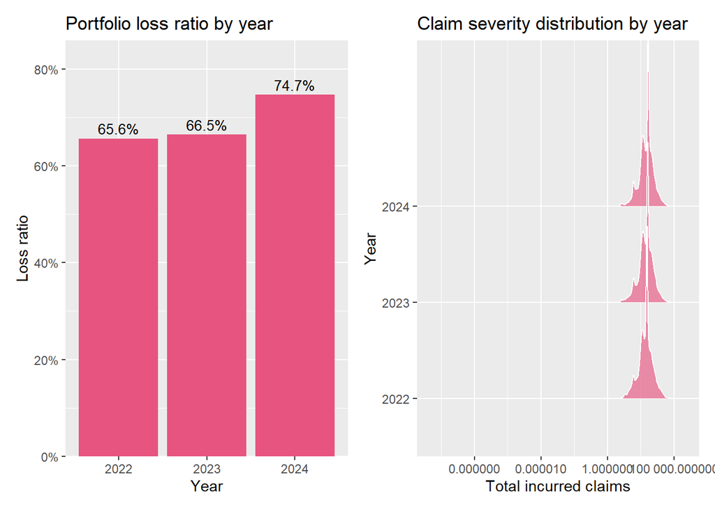

```r
year_perf <- summarise(
  group_by(motor, year),
  total_premium = sum(total_premium, na.rm = TRUE),
  total_incurred = sum(total_incurred, na.rm = TRUE),
  loss_ratio = total_incurred / total_premium
)

p7 <- ggplot(year_perf, aes(x = year, y = loss_ratio)) +
  geom_col(fill = "#e75480") +
  geom_text(aes(label = percent(loss_ratio, accuracy = 0.1)), vjust = -0.4, size = 3.5) +
  scale_y_continuous(labels = percent, expand = expansion(mult = c(0, 0.15))) +
  labs(
    title = "Portfolio loss ratio by year",
    x = "Year",
    y = "Loss ratio"
  )

p8 <- ggplot(
  filter(motor, total_claims > 0, total_incurred > 0),
  aes(x = total_incurred, y = year)
) +
  ggridges::geom_density_ridges(fill = "#e75480", alpha = 0.65, colour = "white") +
  scale_x_log10(labels = label_number()) +
  labs(
    title = "Claim severity distribution by year",
    x = "Total incurred claims",
    y = "Year"
  )

p7 + p8
```

The ridgeline plot shows that claim amounts are highly-right skewed in all three years, with most claim records concentrated at lower values and fewer records extending into higher amounts. While the overall shape is similar across all years, 2024 shows slightly weaker profitability, suggesting that the change may be driven by claim size or portfolio mix rather than a major change in claim distribution.

**Note**

A higher loss ratio means weaker profitability.

### 6.2 Policy Type and Profitability

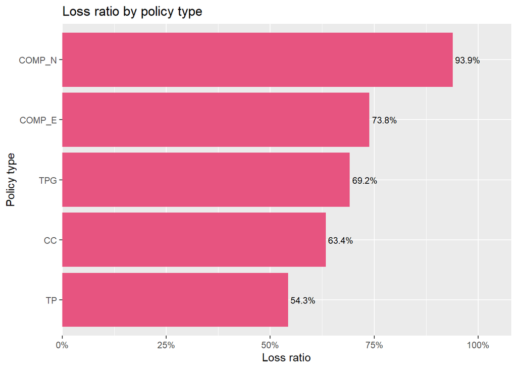

```r
policy_perf <- group_by(motor, policy_type)

policy_perf <- summarise(
  policy_perf,
  records = n(),
  premium = sum(total_premium, na.rm = TRUE),
  incurred = sum(total_incurred, na.rm = TRUE),
  loss_ratio = incurred / premium
)

ggplot(policy_perf, aes(x = loss_ratio, y = reorder(policy_type, loss_ratio))) +
  geom_col(fill = "#e75480") +
  geom_text(
    aes(label = percent(loss_ratio, accuracy = 0.1)),
    hjust = -0.1,
    size = 3
  ) +
  scale_x_continuous(
    labels = percent,
    expand = expansion(mult = c(0, 0.15))
  ) +
  labs(
    title = "Loss ratio by policy type",
    x = "Loss ratio",
    y = "Policy type"
  )
```

The plot shows variation in profitability across policy types. `COMP_N` *(comprehensive without excess)* has the highest loss ratio at **93.9%**, indicating low profitability, while `TP` *(basic coverage)* has the lowest loss ratio at **54.3%**, making it the most profitable segment. Although all the policy types remain below 100% and profitable before expenses, `COMP_N` should be monitored closely.

### 6.3 Claim Rate by Payment Frequency

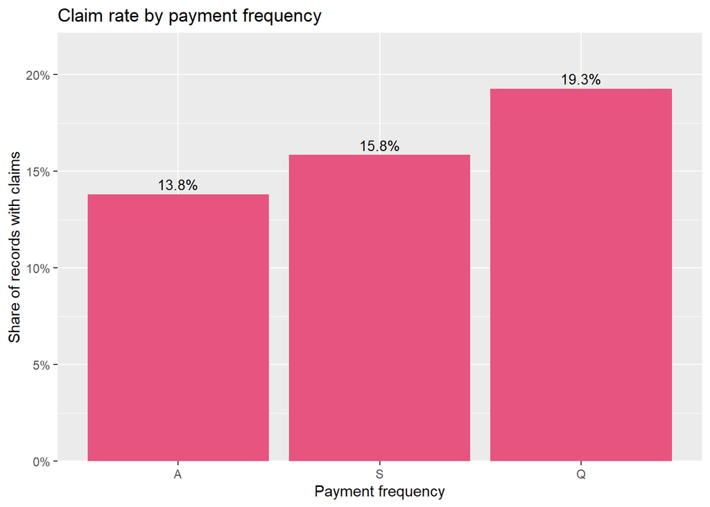

```r
payment_claim <- group_by(motor, payment_frequency)

payment_claim <- summarise(
  payment_claim,
  records = n(),
  claim_rate = mean(claim_flag, na.rm = TRUE)
)

ggplot(payment_claim, aes(x = reorder(payment_frequency, claim_rate), y = claim_rate)) +
  geom_col(fill = "#e75480") +
  geom_text(
    aes(label = percent(claim_rate, accuracy = 0.1)),
    vjust = -0.4,
    size = 3.5
  ) +
  scale_y_continuous(
    labels = percent,
    expand = expansion(mult = c(0, 0.15))
  ) +
  labs(
    title = "Claim rate by payment frequency",
    x = "Payment frequency",
    y = "Share of records with claims"
  )
```

This plot compares how often claims occur across different payment frequencies. Payment groups with **higher claim rates** may indicate **greater claim volatility** and should be reviewed further, even if they represent a smaller share of the portfolio.

### 6.4 Policy Status and Business Type

**Policy Status**

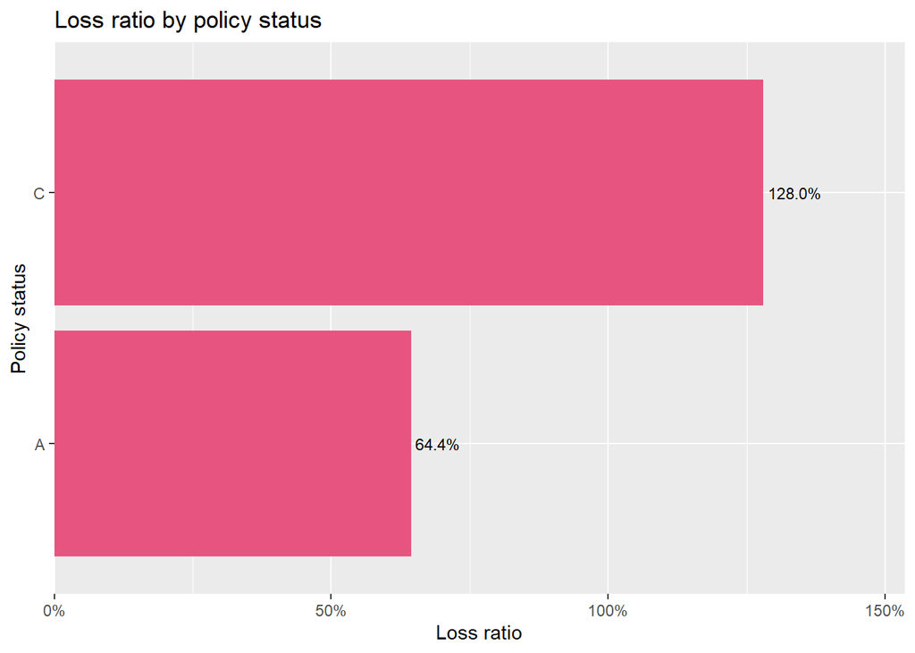

```r
status_perf <- group_by(motor, policy_status)

status_perf <- summarise(
  status_perf,
  records = n(),
  loss_ratio = sum(total_incurred, na.rm = TRUE) / sum(total_premium, na.rm = TRUE)
)

ggplot(status_perf, aes(x = loss_ratio, y = reorder(policy_status, loss_ratio))) +
  geom_col(fill = "#e75480") +
  geom_text(aes(label = percent(loss_ratio, accuracy = 0.1)), hjust = -0.1, size = 3) +
  scale_x_continuous(labels = percent, expand = expansion(mult = c(0, 0.2))) +
  labs(
    title = "Loss ratio by policy status",
    x = "Loss ratio",
    y = "Policy status"
  )
```

**Business Type**

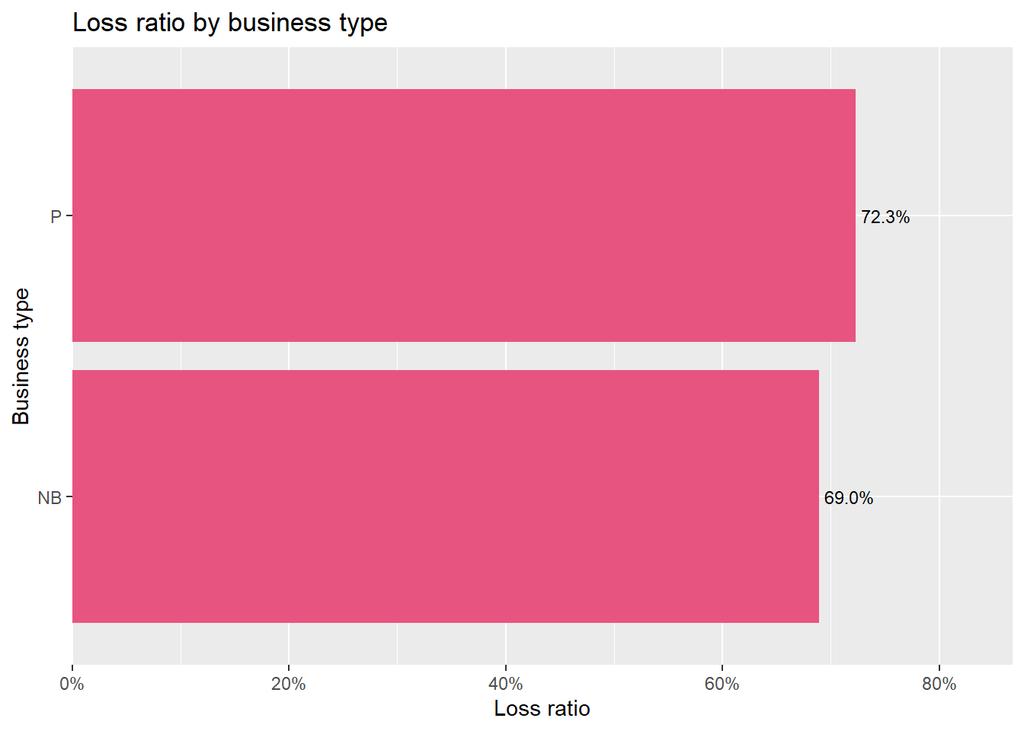

```r
business_perf <- group_by(motor, business_type)

business_perf <- summarise(
  business_perf,
  records = n(),
  loss_ratio = sum(total_incurred, na.rm = TRUE) / sum(total_premium, na.rm = TRUE)
)

ggplot(business_perf, aes(x = loss_ratio, y = reorder(business_type, loss_ratio))) +
  geom_col(fill = "#e75480") +
  geom_text(aes(label = percent(loss_ratio, accuracy = 0.1)), hjust = -0.1, size = 3) +
  scale_x_continuous(labels = percent, expand = expansion(mult = c(0, 0.2))) +
  labs(
    title = "Loss ratio by business type",
    x = "Loss ratio",
    y = "Business type"
  )
```

Policy status and business type show differences in profitability. Groups with higher loss ratios are less profitable because a larger share of their premium is used to cover incurred claims.

### 6.5 Bonus Score and Claim Risk

Bonus score is analysed against claim rate to examine whether different customer risk groups show different levels of claim occurrence.

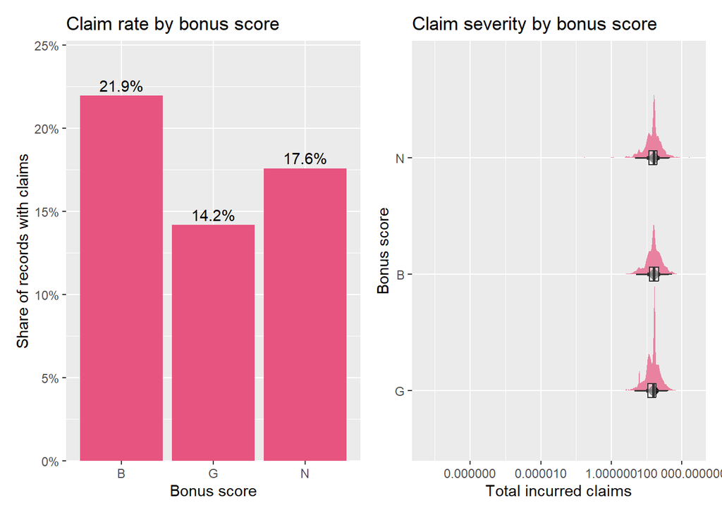

```r
bonus_claim <- summarise(
  group_by(motor, bonus_score),
  records = n(),
  claim_rate = mean(claim_flag, na.rm = TRUE),
  loss_ratio = sum(total_incurred, na.rm = TRUE) / sum(total_premium, na.rm = TRUE)
)

p9 <- ggplot(bonus_claim, aes(x = bonus_score, y = claim_rate)) +
  geom_col(fill = "#e75480") +
  geom_text(aes(label = percent(claim_rate, accuracy = 0.1)), vjust = -0.4) +
  scale_y_continuous(labels = percent, expand = expansion(mult = c(0, 0.15))) +
  labs(
    title = "Claim rate by bonus score",
    x = "Bonus score",
    y = "Share of records with claims"
  )

p10 <- ggplot(
  filter(motor, total_claims > 0, total_incurred > 0, !is.na(bonus_score)),
  aes(x = total_incurred, y = reorder(bonus_score, total_incurred, median))
) +
  ggdist::stat_halfeye(fill = "#e75480", alpha = 0.7, width = 0.6) +
  geom_boxplot(width = 0.12, outlier.shape = NA, alpha = 0.5) +
  scale_x_log10(labels = label_number()) +
  labs(
    title = "Claim severity by bonus score",
    x = "Total incurred claims",
    y = "Bonus score"
  )

p9 + p10
```

The plot shows a clear relationship between bonus score and claim risk.Poor profiles (`B`) have the highest claim rate at **21.9%**, followed by neutral profiles (`N`) at **17.6%**, while favourable profiles (`G`) have the lowest claim rate at **14.2%**. The severity plot shows that claim amounts are still highly skewed across all groups, so bonus score is more useful for identifying claim likelihood than clearly separating claim size.

Claim risk and loss ratio by bonus score

| Bonus.Score | Records | Claim.Rate | Loss.Ratio |
| --- | --- | --- | --- |
| B | 4,730 | 21.9% | 79.0% |
| G | 341,511 | 14.2% | 69.7% |
| N | 7,850 | 17.6% | 81.4% |

Higher claim rates show greater risk, while the table adds loss ratio to show how this translates into profitability.

## 7. Statistical Validation

The bivariate plots suggest that both profitability and claim risk differ across several portfolio segments. To support these observations, statistical tests are applied. Since loss ratio is highly skewed, **non-parametric tests** are used for profitability analysis. For claim occurrence, **Chi-square tests** are used as the outcome is categorical.

### 7.1 Validation of Profitability Differences

**Kruskal–Wallis tests** are used for variables with more than two categories (eg. year, policy type), while **Wilcoxon tests** are applied to variables with two groups (eg. policy status, business type).

Statistical validation of profitability differences

| Analysis | Test | P_Value |
| --- | --- | --- |
| Loss ratio by year | Kruskal-Wallis test | <0.001 |
| Loss ratio by policy type | Kruskal-Wallis test | <0.001 |
| Loss ratio by policy status | Wilcoxon rank-sum test | <0.001 |
| Loss ratio by business type | Wilcoxon rank-sum test | <0.001 |

The profitability tests check whether the loss ratio differs across the selected groups. A small p-value shows that the differences observed are **statistically significant**, meaning that profitability is not evenly distributed across these segments.

### 7.2 Validation of Claim Risk Differences

**Chi-square tests** are used to validate whether claim occurrence is associated with payment frequency and bonus score.

Statistical validation of volatility differences

| Analysis | Test | P_Value |
| --- | --- | --- |
| Claim occurrence by payment frequency | Chi-square test | <0.001 |
| Claim occurrence by bonus score | Chi-square test | <0.001 |

The tests check whether differences in claim occurrence across these groups are **statistically significant**. A small p-value shows that claim risk is not randomly distributed, but associated with these factors.

## 8. Key Findings

### 8.1 Profitability Findings

Overall, the portfolio appears profitable, but performance is not equal across all groups.

- The portfolio loss ratio is **70.3%**, meaning incurred claims are lower than total premiums.
- Profitability changed slightly across the years, with 2024 showing a weaker loss ratio than 2022 and 2023.
- Policy type is a key profitability factor, with clear differences in loss ratios across other policy types.
- Policy status and business type also vary, suggesting that policy lifecycle and business source may affect overall performance.

### 8.2 Volatility and Claim Risk Findings

Claim risk is not evenly spread across the portfolio. Most records are claim-free, but some groups show higher claim occurrence.

- Only **14.3%** of records have at least one claim.
- This shows that while most policies do not have claims, risk is concentrated in the smaller group.
- Payment frequency differs in claim rate, suggesting a relation between payment behaviour and claim occurrence.
- Bonus score is also informative, with poorer claims history associated with higher claim rates.

### 8.3 Statistical Validation Findings

The statistical tests support the main visual findings.

- **Kruskal-Wallis** tests show that loss ratio differs significantly across year and policy type.
- **Wilcoxon** tests shows differences in loss ratio by policy status and business type.
- **Chi-square** tests show that claim occurrence is associated with payment frequency and bonus score.
- However, given the large dataset, statistical significance should be interpreted together with the charts and business context.

## 9. Recommendations

1. **Review weaker policy types first.**  
   Policy type shows clear differences in loss ratio, so segments with higher loss ratios should be reviewed more closely.
2. **Monitor high-risk claim groups.**  
   Payment frequency and bonus score show differences in claim rate, so these groups can be used as early indicators of claim risk.
3. **Explore beyond the overall portfolio result.**  
   The portfolio is profitable overall, but some segments perform weaker than others. Segment-level monitoring is needed so that weaker areas are not hidden by the overall average.
4. **Extend the analysis if needed.**  
   Future work can use modelling techniques to test multiple factors together and better understand which variables have the strongest effect on profitability and claim risk.

## 10. References

- [R for Visual Analytics](https://r4va.netlify.app/)
- [Mendeley Data motor insurance portfolio dataset](https://data.mendeley.com/datasets/sw4jmdb2sm/1)
- [ggridge](https://wilkelab.org/ggridges/index.html)
- [ggdist](https://mjskay.github.io/ggdist/index.html)